# Contents

- 1. Importing & Preprocessing Data
  - 1.1 Problem Statement
  - 1.2 Import Data
  - 1.3 Data Summary & Variable Description
- 2 Expolatory Data Analysis (EDA)
  - 2.1 Within its variable
    - 2.1.1 Dependent/Target Variables
      - 2.1.1.1 Qualitative/Categorical Variables
        - 2.1.1.1.1 ['Transported']
    - 2.1.2 Independent/Response Variables
      - 2.1.2.1 Quantitative/Numerical Variables
      - 2.1.2.2 Qualitative/Categorical Variables
      - 2.1.2.3 Descriptive Variables
        - 2.1.2.3.1 ['PassengerId']
        - 2.1.2.3.2 ['Cabin']
        - 2.1.2.3.3 ['Name']
        - 2.1.2.3.4 Recap
      - 2.1.2.4 Recap -2.2 Inter variables

# 1 Importing & Preprocessing Data

## 1.1 Problem Statement

In 2912, The Spaceship Titanic was an interstellar passenger liner launched a month ago. With almost 13,000 passengers on board, the vessel set out on its maiden voyage transporting emigrants from our solar system to three newly habitable exoplanets orbiting nearby stars. While rounding Alpha Centauri en route to its first destination—the torrid 55 Cancri E—the unwary Spaceship Titanic collided with a spacetime anomaly hidden within a dust cloud. Sadly, it met a similar fate as its namesake from 1000 years before. Though the ship stayed intact, almost half of the passengers were transported to an alternate dimension!.

From this unique case, we have objective to predict whether a passenger was transported to an alternate dimension during the Spaceship Titanic's collision with the spacetime anomaly. We use many classification algorithms for this binary classification case. From what I worked on, the results stated that the Catboost Classifier makes the best classifier algorithm with 0.80734 accuracy on the test set followed by Random Forest, SVM, Decision Trees, KNN, Logistic Regression.

Top 7% in Kaggle

```python
"""
Title: Titanic Spaceship
Author: Rifqi Azhari
Date: 2/27/2024
"""

import sys

# Common libraries
import pandas as pd
import matplotlib.pyplot as plt
import seaborn as sns
import numpy as np


# Library for ignore warnings
import warnings
warnings.filterwarnings('ignore')
```

```python
from IPython.display import Markdown, display
# Printing bold and italic
def printmd(string):
    display(Markdown(string))
printmd("*italic*")
printmd("**bold**")

printmd("**<span style='color:red'>Red text</span>**")

# Printing color
def printmd(string, color=None):
    colorstr = "<span style='color:{}'>{}</span>".format(color, string)
    display(Markdown(colorstr))

printmd("**Crimson**", color="#DC143C")
printmd("**McKinsey**", color="#042440")
printmd("**McKinsey2**", color="#053259")
```

*italic*

**bold**

**Red text**

**Crimson**

**McKinsey**

**McKinsey2**

```python
printmd("**feature extraction**", color="#C78C06")
printmd("**feature extraction**", color="#E1AD01")
```

**feature extraction**

**feature extraction**

```python
custom_pallete = sns.color_palette(['#08FC84', '#0804FC'])
```

## 1.2 Import Data

```python
# Importing data
import pandas as pd
xy_train_raw = pd.read_csv("train.csv")
xy_test_raw = pd.read_csv("test.csv")
print(type(xy_train_raw))
print("xy_train shape: ", xy_train_raw.shape)
print("xy_test shape: ", xy_test_raw.shape, "\n")

# create deep copy
xy_train = xy_train_raw.copy(deep = True)
x_test = xy_test_raw.copy(deep = True)

# split the target and features
x_train = xy_train.drop('Transported', axis=1)
y_train = xy_train['Transported']
y_train = pd.Series.to_frame(y_train)
print(type(x_train))
print("x_train shape: ", x_train.shape)
print("x_test shape: ", x_test.shape)
print(type(y_train))
print("y_train shape: ", y_train.shape, "\n")

# Check the data proportion
print("train data: ", round((len(x_train)/(len(x_train)+len(x_test)))*100, 2), "%")
print("test data: ", round((len(x_test)/(len(x_train)+len(x_test)))*100, 2), "%")
```

```
<class 'pandas.core.frame.DataFrame'>
xy_train shape:  (8693, 14)
xy_test shape:  (4277, 13)

<class 'pandas.core.frame.DataFrame'>
x_train shape:  (8693, 13)
x_test shape:  (4277, 13)
<class 'pandas.core.frame.DataFrame'>
y_train shape:  (8693, 1)

train data:  67.02 %
test data:  32.98 %
```

## 1.3 Data Summary & Variable Description

```
1. PassengerId - A unique Id for each passenger. Each Id takes the form gggg_pp where gggg indicates a group the passenger is travelling with and pp is their number within the group. People in a group are often family members, but not always.
2. HomePlanet - The planet the passenger departed from, typically their planet of permanent residence.
3. CryoSleep - Indicates whether the passenger elected to be put into suspended animation for the duration of the voyage. Passengers in cryosleep are confined to their cabins.
4. Cabin - The cabin number where the passenger is staying. Takes the form deck/num/side, where side can be either P for Port or S for Starboard.
5. Destination - The planet the passenger will be debarking to.
6. Age - The age of the passenger.
7. VIP - Whether the passenger has paid for special VIP service during the voyage.
8. RoomService, FoodCourt, ShoppingMall, Spa, VRDeck - Amount the passenger has billed at each of the Spaceship Titanic's many luxury amenities.
9. Name - The first and last names of the passenger.
10. Transported - Whether the passenger was transported to another dimension. This is the target, the column you are trying to predict.
```

```python
# Peeking the data
print(x_train.info())
x_train.sample(3)
```

```
<class 'pandas.core.frame.DataFrame'>
RangeIndex: 8693 entries, 0 to 8692
Data columns (total 13 columns):
 #   Column        Non-Null Count  Dtype
---  ------        --------------  -----
 0   PassengerId   8693 non-null   object
 1   HomePlanet    8492 non-null   object
 2   CryoSleep     8476 non-null   object
 3   Cabin         8494 non-null   object
 4   Destination   8511 non-null   object
 5   Age           8514 non-null   float64
 6   VIP           8490 non-null   object
 7   RoomService   8512 non-null   float64
 8   FoodCourt     8510 non-null   float64
 9   ShoppingMall  8485 non-null   float64
 10  Spa           8510 non-null   float64
 11  VRDeck        8505 non-null   float64
 12  Name          8493 non-null   object
dtypes: float64(6), object(7)
memory usage: 883.0+ KB
None
```

|  | PassengerId | HomePlanet | CryoSleep | Cabin | Destination | Age | VIP | RoomService | FoodCourt | ShoppingMall | Spa | VRDeck | Name |
| --- | --- | --- | --- | --- | --- | --- | --- | --- | --- | --- | --- | --- | --- |
| 1663 | 1764_02 | Mars | False | E/134/S | TRAPPIST-1e | 18.0 | False | 0.0 | 0.0 | 0.0 | 0.0 | 0.0 | Cin Laai |
| 2149 | 2305_01 | Earth | True | G/368/S | TRAPPIST-1e | 60.0 | False | 0.0 | 0.0 | 0.0 | 0.0 | 0.0 | NaN |
| 4606 | 4909_01 | Earth | False | F/997/P | 55 Cancri e | 59.0 | False | 460.0 | 139.0 | 0.0 | 1.0 | 0.0 | Evane Franey |

```python
# Peeking the data
print(y_train.info())
y_train.sample(5)
```

```
<class 'pandas.core.frame.DataFrame'>
RangeIndex: 8693 entries, 0 to 8692
Data columns (total 1 columns):
 #   Column       Non-Null Count  Dtype
---  ------       --------------  -----
 0   Transported  8693 non-null   bool
dtypes: bool(1)
memory usage: 8.6 KB
None
```

|  | Transported |
| --- | --- |
| 879 | False |
| 7187 | True |
| 45 | True |
| 3797 | True |
| 3116 | True |

```python
# Peeking the data
print(x_test.info())
x_test.sample(5)
```

```
<class 'pandas.core.frame.DataFrame'>
RangeIndex: 4277 entries, 0 to 4276
Data columns (total 13 columns):
 #   Column        Non-Null Count  Dtype
---  ------        --------------  -----
 0   PassengerId   4277 non-null   object
 1   HomePlanet    4190 non-null   object
 2   CryoSleep     4184 non-null   object
 3   Cabin         4177 non-null   object
 4   Destination   4185 non-null   object
 5   Age           4186 non-null   float64
 6   VIP           4184 non-null   object
 7   RoomService   4195 non-null   float64
 8   FoodCourt     4171 non-null   float64
 9   ShoppingMall  4179 non-null   float64
 10  Spa           4176 non-null   float64
 11  VRDeck        4197 non-null   float64
 12  Name          4183 non-null   object
dtypes: float64(6), object(7)
memory usage: 434.5+ KB
None
```

|  | PassengerId | HomePlanet | CryoSleep | Cabin | Destination | Age | VIP | RoomService | FoodCourt | ShoppingMall | Spa | VRDeck | Name |
| --- | --- | --- | --- | --- | --- | --- | --- | --- | --- | --- | --- | --- | --- |
| 716 | 1472_01 | Earth | True | G/236/P | PSO J318.5-22 | 29.0 | False | 0.0 | 0.0 | 0.0 | 0.0 | 0.0 | Kimena Dillips |
| 3808 | 8340_03 | Europa | False | B/275/P | TRAPPIST-1e | 29.0 | False | 0.0 | 2405.0 | 0.0 | 1088.0 | 1757.0 | Axionin Obnoftle |
| 4092 | 8911_01 | Mars | False | D/279/P | TRAPPIST-1e | 43.0 | True | 12.0 | 0.0 | 1039.0 | 6.0 | 0.0 | Barave Late |
| 112 | 0256_01 | Earth | False | F/48/S | PSO J318.5-22 | 41.0 | False | 0.0 | 0.0 | 728.0 | 0.0 | 0.0 | Kerryn Bensley |
| 2133 | 4626_02 | Europa | False | C/174/S | NaN | 27.0 | False | 1218.0 | 236.0 | 0.0 | 1678.0 | 0.0 | Alaron Sofraten |

```python
# Counting the numerical features
numCols = list(x_train.select_dtypes(exclude='object').columns)
print(f"There are {len(numCols)} numerical features:\n", numCols)
```

```
There are 6 numerical features:
 ['Age', 'RoomService', 'FoodCourt', 'ShoppingMall', 'Spa', 'VRDeck']
```

```python
# Counting the categorical features
catCols = list(x_train.select_dtypes(include='object').columns)
print(f"There are {len(catCols)} categorical features:\n", catCols)
```

```
There are 7 categorical features:
 ['PassengerId', 'HomePlanet', 'CryoSleep', 'Cabin', 'Destination', 'VIP', 'Name']
```

# 2 Expolatory Data Analysis (EDA)

To make visualization and feature extraction easier i will use xy_train instead of x_train

```python
# For doing feature engineering of training and test data at the same time
x_cleaner = [xy_train, x_test]
```

```python
print("xy_train: ", xy_train.shape)
print("x_test: ", x_test.shape)
```

```
xy_train:  (8693, 14)
x_test:  (4277, 13)
```

## 2.1 Early filter of missing data

```python
# Checking missing values
print(f"There is {sum(xy_train['Transported'].isnull())} missing data in target variable.")
```

```
There is 0 missing data in target variable.
```

```python
# Checking missing values
m_train = pd.DataFrame({'x_train(Σ)': xy_train.isnull().sum(),'x_train(%)': xy_train.isnull().sum() / len(x_train) * 100})
m_train = m_train[m_train['x_train(Σ)'] > 0]
m_train.sort_values(by='x_train(Σ)', ascending=False, inplace=True)
print(f"There are {m_train.shape[0]} features having missing data in training set.")

m_test = pd.DataFrame({'x_test(Σ)': x_test.isnull().sum(),'x_test(%)': x_test.isnull().sum() / len(x_test) * 100})
m_test = m_test[m_test['x_test(Σ)'] > 0]
m_test.sort_values(by='x_test(Σ)', ascending=False, inplace=True)
print(f"There are {m_test.shape[0]} features having missing data in test set.")

missing = pd.concat([m_train, m_test], axis=1)
missing
```

```
There are 12 features having missing data in training set.
There are 12 features having missing data in test set.
```

|  | x_train(Σ) | x_train(%) | x_test(Σ) | x_test(%) |
| --- | --- | --- | --- | --- |
| CryoSleep | 217 | 2.496261 | 93 | 2.174421 |
| ShoppingMall | 208 | 2.392730 | 98 | 2.291326 |
| VIP | 203 | 2.335212 | 93 | 2.174421 |
| HomePlanet | 201 | 2.312205 | 87 | 2.034136 |
| Name | 200 | 2.300702 | 94 | 2.197802 |
| Cabin | 199 | 2.289198 | 100 | 2.338087 |
| VRDeck | 188 | 2.162660 | 80 | 1.870470 |
| FoodCourt | 183 | 2.105142 | 106 | 2.478373 |
| Spa | 183 | 2.105142 | 101 | 2.361468 |
| Destination | 182 | 2.093639 | 92 | 2.151040 |
| RoomService | 181 | 2.082135 | 82 | 1.917232 |
| Age | 179 | 2.059128 | 91 | 2.127660 |

There is no variable that has missing value more than 10% of its proportion. We could continue without deleting any variable

## 2.1 Within its variable

From definition, sample, dispersion, we will decide the exact type of each variable

```python
print("There are", len(numCols), "numerical features:\n", numCols, "\n")
print("There are", len(catCols), "numerical features:\n", catCols)
```

```
There are 6 numerical features:
 ['Age', 'RoomService', 'FoodCourt', 'ShoppingMall', 'Spa', 'VRDeck']

There are 7 numerical features:
 ['PassengerId', 'HomePlanet', 'CryoSleep', 'Cabin', 'Destination', 'VIP', 'Name']
```

```python
#CHECK CONTINUOUS OR DISCRETE HERE (FROM THE VALUE SAMPLE)
#CHECK ORDINAL OR NOMINAL HERE (FROM THE VALUE SAMPLE)
x_train['Name'].head(5)
```

```
0      Maham Ofracculy
1         Juanna Vines
2        Altark Susent
3         Solam Susent
4    Willy Santantines
Name: Name, dtype: object
```

```python
#CHECK CONTINUOUS OR DISCRETE HERE (FROM THE VALUE DISPERSION)
#CHECK ORDINAL OR NOMINAL HERE (FROM THE VALUE DISPERSION)
x_train['Name'].value_counts()
```

```
Name
Gollux Reedall        2
Elaney Webstephrey    2
Grake Porki           2
Sus Coolez            2
Apix Wala             2
                     ..
Jamela Griffy         1
Hardy Griffy          1
Salley Mckinn         1
Mall Frasp            1
Propsh Hontichre      1
Name: count, Length: 8473, dtype: int64
```

From 6 detected numerical features: typical: number of bedroom=discrete, area of=continuous

```
- Continuous  ['Age', 'RoomService', 'FoodCourt', 'ShoppingMall', 'Spa', 'VRDeck']
- Discrete    []
- Ordinal     []
- Nominal     []
- Other       []
```

From 7 detected categorical features:

```
- Ordinal     []
- Nominal     ['HomePlanet', 'Destination']
- Binary      ['CryoSleep', 'VIP']
- Other       ['PassengerId', 'Cabin', 'Name']
```

### 2.1.1 Dependent/Target Variable

#### 2.1.1.1 Qualitative/Categorical Variables

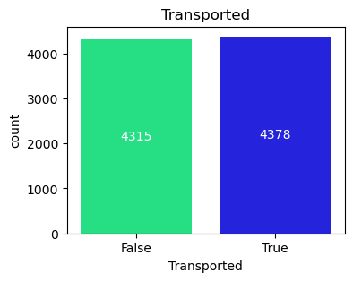

```python
# Plotting current target
import matplotlib.pyplot as plt
import seaborn as sns
plt.figure(figsize=(4,3))
ax = sns.countplot(data=xy_train, x='Transported', hue='Transported', legend=False, palette=custom_pallete)
ax.bar_label(ax.containers[0], label_type='center', color='white')
ax.bar_label(ax.containers[1], label_type='center', color='white')
plt.title('Transported')
```

### 2.1.2 Independent/Response Variables

#### 2.1.2.1 Quantitative/Numerical Variables

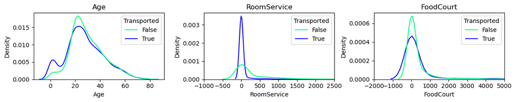

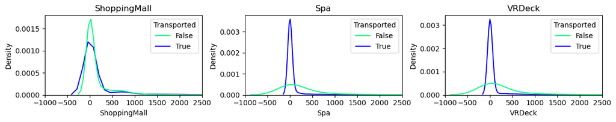

```python
# Plotting current features
# 1ST
fig=plt.figure(figsize=(12,2.5))
plt.subplot(1,3,1)
sns.kdeplot(data=xy_train, x='Age', hue='Transported', palette=custom_pallete)
title = plt.title("Age")

plt.subplot(1,3,2)
sns.kdeplot(data=xy_train, x='RoomService', hue='Transported', palette=custom_pallete)
title = plt.title("RoomService")
plt.xlim([-1000,2500])

plt.subplot(1,3,3)
sns.kdeplot(data=xy_train, x='FoodCourt', hue='Transported', palette=custom_pallete)
title = plt.title("FoodCourt")
plt.xlim([-2000,5000])
fig.tight_layout()

# 2ND
fig=plt.figure(figsize=(12,2.5))
plt.subplot(1,3,1)
sns.kdeplot(data=xy_train, x='ShoppingMall', hue='Transported', palette=custom_pallete)
title = plt.title("ShoppingMall")
plt.xlim([-1000,2500])

plt.subplot(1,3,2)
sns.kdeplot(data=xy_train, x='Spa', hue='Transported', palette=custom_pallete)
title = plt.title("Spa")
plt.xlim([-1000,2500])

plt.subplot(1,3,3)
sns.kdeplot(data=xy_train, x='VRDeck', hue='Transported', palette=custom_pallete)
title = plt.title("VRDeck")
plt.xlim([-1000,2500])
fig.tight_layout()
```

**missing values**

**before**

```
There are 12 features having missing data in training set.
There are 12 features having missing data in test set.
              x_train(Σ)  x_train(%)  x_test(Σ)  x_test(%)
CryoSleep            217    2.496261         93   2.174421
ShoppingMall         208    2.392730         98   2.291326
VIP                  203    2.335212         93   2.174421
HomePlanet           201    2.312205         87   2.034136
Name                 200    2.300702         94   2.197802
Cabin                199    2.289198        100   2.338087
VRDeck               188    2.162660         80   1.870470
FoodCourt            183    2.105142        106   2.478373
Spa                  183    2.105142        101   2.361468
Destination          182    2.093639         92   2.151040
RoomService          181    2.082135         82   1.917232
Age                  179    2.059128         91   2.127660
```

**after**

```
There are 6 features having missing data in training set.
There are 6 features having missing data in test set.
             x_train(Σ)  x_train(%)  x_test(Σ)  x_test(%)
CryoSleep           217    2.496261         93   2.174421
VIP                 203    2.335212         93   2.174421
HomePlanet          201    2.312205         87   2.034136
Name                200    2.300702         94   2.197802
Cabin               199    2.289198        100   2.338087
Destination         182    2.093639         92   2.151040
```

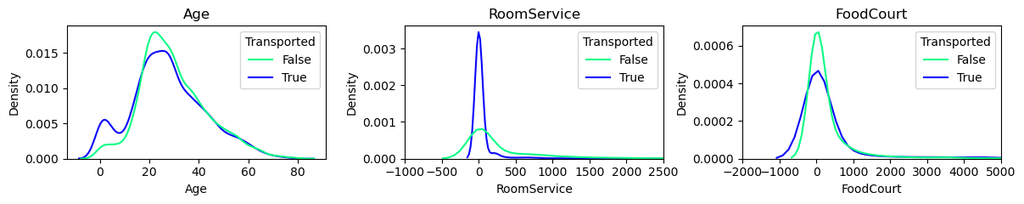

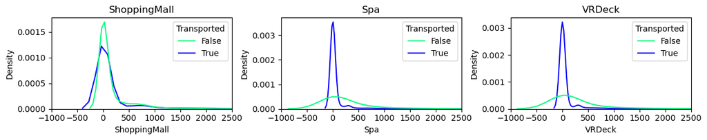

```python
# Missing values
printmd("**missing values**", color="#08FC84")
printmd("**before**", color="#0804FC")
m_train = pd.DataFrame({'x_train(Σ)': xy_train.isnull().sum(),'x_train(%)': xy_train.isnull().sum() / len(x_train) * 100})
m_train = m_train[m_train['x_train(Σ)'] > 0]
m_train.sort_values(by='x_train(Σ)', ascending=False, inplace=True)
print(f"There are {m_train.shape[0]} features having missing data in training set.")
m_test = pd.DataFrame({'x_test(Σ)': x_test.isnull().sum(),'x_test(%)': x_test.isnull().sum() / len(x_test) * 100})
m_test = m_test[m_test['x_test(Σ)'] > 0]
m_test.sort_values(by='x_test(Σ)', ascending=False, inplace=True)
print(f"There are {m_test.shape[0]} features having missing data in test set.")
missing = pd.concat([m_train, m_test], axis=1)
print(missing)

for data in x_cleaner:
    # Filling missing values (mean)
    data['Age'] = data['Age'].fillna(data['Age'].mean())
    data['RoomService'] = data['RoomService'].fillna(data['RoomService'].mean())
    data['FoodCourt'] = data['FoodCourt'].fillna(data['FoodCourt'].mean())
    data['ShoppingMall'] = data['ShoppingMall'].fillna(data['ShoppingMall'].mean())
    data['Spa'] = data['Spa'].fillna(data['Spa'].mean())
    data['VRDeck'] = data['VRDeck'].fillna(data['VRDeck'].mean())

printmd("**after**", color="#0804FC")
m_train = pd.DataFrame({'x_train(Σ)': xy_train.isnull().sum(),'x_train(%)': xy_train.isnull().sum() / len(x_train) * 100})
m_train = m_train[m_train['x_train(Σ)'] > 0]
m_train.sort_values(by='x_train(Σ)', ascending=False, inplace=True)
print(f"There are {m_train.shape[0]} features having missing data in training set.")
m_test = pd.DataFrame({'x_test(Σ)': x_test.isnull().sum(),'x_test(%)': x_test.isnull().sum() / len(x_test) * 100})
m_test = m_test[m_test['x_test(Σ)'] > 0]
m_test.sort_values(by='x_test(Σ)', ascending=False, inplace=True)
print(f"There are {m_test.shape[0]} features having missing data in test set.")
missing = pd.concat([m_train, m_test], axis=1)
print(missing)

# Plotting filled features
# 1ST
fig=plt.figure(figsize=(12,2.5))
plt.subplot(1,3,1)
sns.kdeplot(data=xy_train, x='Age', hue='Transported', palette=custom_pallete)
title = plt.title("Age")

plt.subplot(1,3,2)
sns.kdeplot(data=xy_train, x='RoomService', hue='Transported', palette=custom_pallete)
title = plt.title("RoomService")
plt.xlim([-1000,2500])

plt.subplot(1,3,3)
sns.kdeplot(data=xy_train, x='FoodCourt', hue='Transported', palette=custom_pallete)
title = plt.title("FoodCourt")
plt.xlim([-2000,5000])
fig.tight_layout()

# 2ND
fig=plt.figure(figsize=(12,2.5))
plt.subplot(1,3,1)
sns.kdeplot(data=xy_train, x='ShoppingMall', hue='Transported', palette=custom_pallete)
title = plt.title("ShoppingMall")
plt.xlim([-1000,2500])

plt.subplot(1,3,2)
sns.kdeplot(data=xy_train, x='Spa', hue='Transported', palette=custom_pallete)
title = plt.title("Spa")
plt.xlim([-1000,2500])

plt.subplot(1,3,3)
sns.kdeplot(data=xy_train, x='VRDeck', hue='Transported', palette=custom_pallete)
title = plt.title("VRDeck")
plt.xlim([-1000,2500])
fig.tight_layout()
```

As we can see, the distribution doesnt change that much. Its because the null value only around 2 percent of its proportion

The ['Age'] variable has a unique pattern, we will discretize this value with custom range adjusted to the pattern shown in the distribution

**feature extraction**

**before**

```
xy_train:  (8693, 14)
x_test:  (4277, 13)
```

**after**

```
xy_train:  (8693, 15)
x_test:  (4277, 14)
```

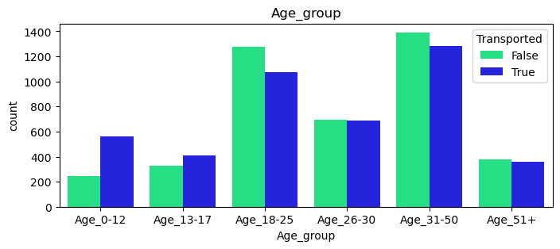

```python
# Feature extraction
printmd("**feature extraction**", color="#08FC84")
printmd("**before**", color="#0804FC")
print("xy_train: ", xy_train.shape)
print("x_test: ", x_test.shape)

import numpy as np
for data in x_cleaner:
    # Adding new feature (['Age_group'] from ['Age'])
    data['Age_group']=np.nan
    data.loc[data['Age']<=12,'Age_group']='Age_0-12'
    data.loc[(data['Age']>12) & (data['Age']<18),'Age_group']='Age_13-17'
    data.loc[(data['Age']>=18) & (data['Age']<=25),'Age_group']='Age_18-25'
    data.loc[(data['Age']>25) & (data['Age']<=30),'Age_group']='Age_26-30'
    data.loc[(data['Age']>30) & (data['Age']<=50),'Age_group']='Age_31-50'
    data.loc[data['Age']>50,'Age_group']='Age_51+'

printmd("**after**", color="#0804FC")
print("xy_train: ", xy_train.shape)
print("x_test: ", x_test.shape)

# Plotting new feature
plt.figure(figsize=(8,3))
g=sns.countplot(data=xy_train, x='Age_group', hue='Transported', order=['Age_0-12','Age_13-17','Age_18-25','Age_26-30','Age_31-50','Age_51+'], palette=custom_pallete)
plt.title('Age_group')
```

ADD: ['Age_group']

['RoomService', 'FoodCourt', 'ShoppingMall', 'Spa', 'VRDeck'] variables have same meaning which is a money expenditure. So in the next box, we will add a new variable.

**feature extraction**

**before**

```
xy_train:  (8693, 15)
x_test:  (4277, 14)
```

**after**

```
xy_train:  (8693, 16)
x_test:  (4277, 15)
```

```
(0.0, 14000.0)
```

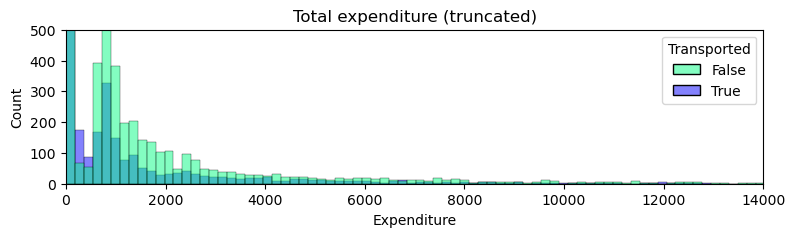

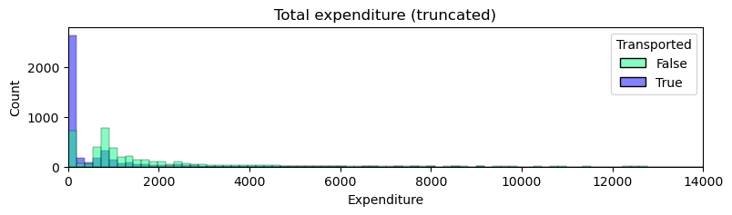

```python
# Feature extraction
printmd("**feature extraction**", color="#08FC84")
printmd("**before**", color="#0804FC")
print("xy_train: ", xy_train.shape)
print("x_test: ", x_test.shape)

Expenditures=['RoomService', 'FoodCourt', 'ShoppingMall', 'Spa', 'VRDeck']
for data in x_cleaner:
    # Adding new feature (['Expenditure'] from ['RoomService', 'FoodCourt', 'ShoppingMall', 'Spa', 'VRDeck'])
    data['Expenditure']=data[Expenditures].sum(axis=1)

printmd("**after**", color="#0804FC")
print("xy_train: ", xy_train.shape)
print("x_test: ", x_test.shape)

# Plotting new feature
fig=plt.figure(figsize=(9,2))
sns.histplot(data=xy_train, x='Expenditure', hue='Transported', bins=200, palette=custom_pallete)
plt.title('Total expenditure (truncated)')
plt.ylim([0,500])
plt.xlim([0,14000])

fig=plt.figure(figsize=(9,2))
sns.histplot(data=xy_train, x='Expenditure', hue='Transported', bins=200, palette=custom_pallete)
plt.title('Total expenditure (truncated)')
plt.ylim([0,2800])
plt.xlim([0,14000])
```

From the accumulation we can see that the distribution has a unique pattern. The count at value equal to 0 is very high. So I will add new binary variable that split the value equal to 0 and not equal to 0

**feature extraction**

**before**

```
xy_train:  (8693, 16)
x_test:  (4277, 15)
```

**after**

```
xy_train:  (8693, 17)
x_test:  (4277, 16)
```

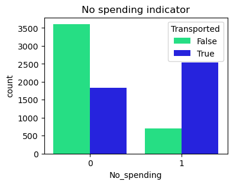

```python
# Feature extraction
printmd("**feature extraction**", color="#08FC84")
printmd("**before**", color="#0804FC")
print("xy_train: ", xy_train.shape)
print("x_test: ", x_test.shape)

for data in x_cleaner:
    # Adding new feature (['No_spending'] from ['Expenditure'])
    data['No_spending']=(data['Expenditure']==0).astype(int)

printmd("**after**", color="#0804FC")
print("xy_train: ", xy_train.shape)
print("x_test: ", x_test.shape)

# Plotting new feature
fig=plt.figure(figsize=(4,3))
sns.countplot(data=xy_train, x='No_spending', hue='Transported', palette=custom_pallete)
plt.title('No spending indicator')
```

ADD: ['Expenditure', 'No_spending']

```python
# summary
# missing value
    # missing value in ['Age', 'RoomService', 'FoodCourt', 'ShoppingMall', 'Spa', 'VRDeck'] filled with mean

# Feature extraction
    # added ['Age_group'] from ['Age']
    # added  ['Expenditure'] from ['RoomService', 'FoodCourt', 'ShoppingMall', 'Spa', 'VRDeck']
        # added ['No_spending'] from ['Expenditure']
```

```python
# Checking missing values
m_train = pd.DataFrame({'x_train(Σ)': xy_train.isnull().sum(),'x_train(%)': xy_train.isnull().sum() / len(x_train) * 100})
m_train = m_train[m_train['x_train(Σ)'] > 0]
m_train.sort_values(by='x_train(Σ)', ascending=False, inplace=True)
print(f"There are {m_train.shape[0]} features having missing data in training set.")

m_test = pd.DataFrame({'x_test(Σ)': x_test.isnull().sum(),'x_test(%)': x_test.isnull().sum() / len(x_test) * 100})
m_test = m_test[m_test['x_test(Σ)'] > 0]
m_test.sort_values(by='x_test(Σ)', ascending=False, inplace=True)
print(f"There are {m_test.shape[0]} features having missing data in test set.")

missing = pd.concat([m_train, m_test], axis=1)
missing
```

```
There are 6 features having missing data in training set.
There are 6 features having missing data in test set.
```

|  | x_train(Σ) | x_train(%) | x_test(Σ) | x_test(%) |
| --- | --- | --- | --- | --- |
| CryoSleep | 217 | 2.496261 | 93 | 2.174421 |
| VIP | 203 | 2.335212 | 93 | 2.174421 |
| HomePlanet | 201 | 2.312205 | 87 | 2.034136 |
| Name | 200 | 2.300702 | 94 | 2.197802 |
| Cabin | 199 | 2.289198 | 100 | 2.338087 |
| Destination | 182 | 2.093639 | 92 | 2.151040 |

#### 2.1.2.2 Qualitative/Categorical Variables

```
['RoomService', 'FoodCourt', 'ShoppingMall', 'Spa', 'VRDeck', 'Age'] fill with mean
['HomePlanet', 'CryoSleep', 'Destination', 'VIP', 'Age_group'] fill with mode
['Surname', 'Family_size', 'Cabin_deck', 'Cabin_number', 'Cabin_side']
```

##### 2.1.2.2.1 ['HomePlanet', 'CryoSleep', 'Destination', 'VIP']

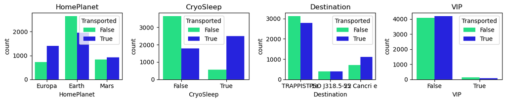

```python
# Plotting current features
fig=plt.figure(figsize=(12,2.5))
plt.subplot(1,4,1)
sns.countplot(data=xy_train, x='HomePlanet', hue='Transported', palette=custom_pallete)
title = plt.title("HomePlanet")

plt.subplot(1,4,2)
sns.countplot(data=xy_train, x='CryoSleep', hue='Transported', palette=custom_pallete)
title = plt.title("CryoSleep")

plt.subplot(1,4,3)
sns.countplot(data=xy_train, x='Destination', hue='Transported', palette=custom_pallete)
title = plt.title("Destination")

plt.subplot(1,4,4)
sns.countplot(data=xy_train, x='VIP', hue='Transported', palette=custom_pallete)
title = plt.title("VIP")
fig.tight_layout()
```

**missing value**

**before**

```
There are 6 features having missing data in training set.
There are 6 features having missing data in test set.
             x_train(Σ)  x_train(%)  x_test(Σ)  x_test(%)
CryoSleep           217    2.496261         93   2.174421
VIP                 203    2.335212         93   2.174421
HomePlanet          201    2.312205         87   2.034136
Name                200    2.300702         94   2.197802
Cabin               199    2.289198        100   2.338087
Destination         182    2.093639         92   2.151040
```

**after**

```
There are 2 features having missing data in training set.
There are 2 features having missing data in test set.
       x_train(Σ)  x_train(%)  x_test(Σ)  x_test(%)
Name          200    2.300702         94   2.197802
Cabin         199    2.289198        100   2.338087
```

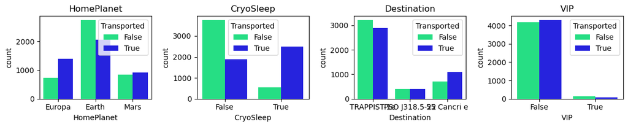

```python
# Missing values
printmd("**missing value**", color="#08FC84")
printmd("**before**", color="#0804FC")
m_train = pd.DataFrame({'x_train(Σ)': xy_train.isnull().sum(),'x_train(%)': xy_train.isnull().sum() / len(x_train) * 100})
m_train = m_train[m_train['x_train(Σ)'] > 0]
m_train.sort_values(by='x_train(Σ)', ascending=False, inplace=True)
print(f"There are {m_train.shape[0]} features having missing data in training set.")
m_test = pd.DataFrame({'x_test(Σ)': x_test.isnull().sum(),'x_test(%)': x_test.isnull().sum() / len(x_test) * 100})
m_test = m_test[m_test['x_test(Σ)'] > 0]
m_test.sort_values(by='x_test(Σ)', ascending=False, inplace=True)
print(f"There are {m_test.shape[0]} features having missing data in test set.")
missing = pd.concat([m_train, m_test], axis=1)
print(missing)

for data in x_cleaner:
    # Filling missing values (mode)
    data['HomePlanet'] = data['HomePlanet'].fillna(data['HomePlanet'].mode()[0])
    data['CryoSleep'] = data['CryoSleep'].fillna(data['CryoSleep'].mode()[0])
    data['Destination'] = data['Destination'].fillna(data['Destination'].mode()[0])
    data['VIP'] = data['VIP'].fillna(data['VIP'].mode()[0])

printmd("**after**", color="#0804FC")
m_train = pd.DataFrame({'x_train(Σ)': xy_train.isnull().sum(),'x_train(%)': xy_train.isnull().sum() / len(x_train) * 100})
m_train = m_train[m_train['x_train(Σ)'] > 0]
m_train.sort_values(by='x_train(Σ)', ascending=False, inplace=True)
print(f"There are {m_train.shape[0]} features having missing data in training set.")
m_test = pd.DataFrame({'x_test(Σ)': x_test.isnull().sum(),'x_test(%)': x_test.isnull().sum() / len(x_test) * 100})
m_test = m_test[m_test['x_test(Σ)'] > 0]
m_test.sort_values(by='x_test(Σ)', ascending=False, inplace=True)
print(f"There are {m_test.shape[0]} features having missing data in test set.")
missing = pd.concat([m_train, m_test], axis=1)
print(missing)

# Plotting filled features
fig=plt.figure(figsize=(12,2.5))
plt.subplot(1,4,1)
sns.countplot(data=xy_train, x='HomePlanet', hue='Transported', palette=custom_pallete)
title = plt.title("HomePlanet")

plt.subplot(1,4,2)
sns.countplot(data=xy_train, x='CryoSleep', hue='Transported', palette=custom_pallete)
title = plt.title("CryoSleep")

plt.subplot(1,4,3)
sns.countplot(data=xy_train, x='Destination', hue='Transported', palette=custom_pallete)
title = plt.title("Destination")

plt.subplot(1,4,4)
sns.countplot(data=xy_train, x='VIP', hue='Transported', palette=custom_pallete)
title = plt.title("VIP")
fig.tight_layout()
```

```python
# summary
# missing value
    # missing value in ['Age', 'RoomService', 'FoodCourt', 'ShoppingMall', 'Spa', 'VRDeck'] filled with mean

# Feature extraction
    # added ['Age_group'] from ['Age']
    # added  ['Expenditure'] from ['RoomService', 'FoodCourt', 'ShoppingMall', 'Spa', 'VRDeck']
        # added ['No_spending'] from ['Expenditure']
```

```python
# Checking missing values
m_train = pd.DataFrame({'x_train(Σ)': xy_train.isnull().sum(),'x_train(%)': xy_train.isnull().sum() / len(x_train) * 100})
m_train = m_train[m_train['x_train(Σ)'] > 0]
m_train.sort_values(by='x_train(Σ)', ascending=False, inplace=True)
print(f"There are {m_train.shape[0]} features having missing data in training set.")

m_test = pd.DataFrame({'x_test(Σ)': x_test.isnull().sum(),'x_test(%)': x_test.isnull().sum() / len(x_test) * 100})
m_test = m_test[m_test['x_test(Σ)'] > 0]
m_test.sort_values(by='x_test(Σ)', ascending=False, inplace=True)
print(f"There are {m_test.shape[0]} features having missing data in test set.")

missing = pd.concat([m_train, m_test], axis=1)
missing
```

```
There are 2 features having missing data in training set.
There are 2 features having missing data in test set.
```

|  | x_train(Σ) | x_train(%) | x_test(Σ) | x_test(%) |
| --- | --- | --- | --- | --- |
| Name | 200 | 2.300702 | 94 | 2.197802 |
| Cabin | 199 | 2.289198 | 100 | 2.338087 |

#### 2.1.2.3 Descriptive Variables

##### 2.1.2.3.1 ['PassengerId']

PassengerID has gggg_pp pattern where:

```
gggg: indicates a group the passenger is travelling with
      people in the group often family (not always)
pp:   is their number within the group
```

```python
xy_train['PassengerId'].head(3)
```

```
0    0001_01
1    0002_01
2    0003_01
Name: PassengerId, dtype: object
```

I will split the gggg and pp using its delimiter but I will not use the pp variable since its way to specific and wont have any meaningful value in our prediction

**feature extraction**

**before**

```
xy_train:  (8693, 17)
x_test:  (4277, 16)
```

**after**

```
xy_train:  (8693, 18)
x_test:  (4277, 17)
```

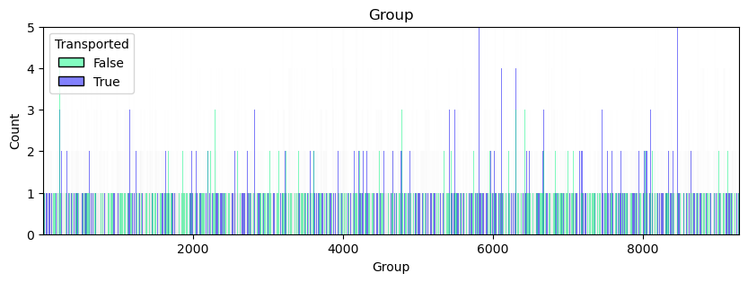

```python
# Feature extraction
printmd("**feature extraction**", color="#08FC84")
printmd("**before**", color="#0804FC")
print("xy_train: ", xy_train.shape)
print("x_test: ", x_test.shape)

for data in x_cleaner:
    # Adding new feature (['Group'] from ['PassengerId'])
    data['Group'] = data['PassengerId'].apply(lambda x: x.split('_')[0]).astype(int)

printmd("**after**", color="#0804FC")
print("xy_train: ", xy_train.shape)
print("x_test: ", x_test.shape)

# Plotting new feature
plt.figure(figsize=(10,3))
sns.histplot(data=xy_train, x='Group', hue='Transported', binwidth=1, palette=custom_pallete)
plt.title('Group')
plt.ylim([0,5])
plt.xlim([1,9280])
fig.tight_layout()
```

['Group'] variable is a categorical ordinal variable, but since it has very high cardinality it will explode when we do one-hot encoding. We will add a new variable instead, we will group 'Group' variable by its count value

**feature extraction**

**before**

```
xy_train:  (8693, 18)
x_test:  (4277, 17)
```

**after**

```
xy_train:  (8693, 19)
x_test:  (4277, 18)
```

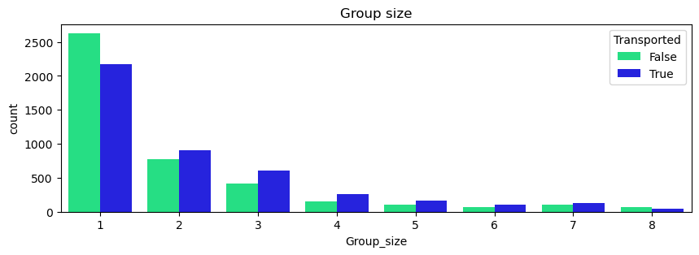

```python
# Feature extraction
printmd("**feature extraction**", color="#08FC84")
printmd("**before**", color="#0804FC")
print("xy_train: ", xy_train.shape)
print("x_test: ", x_test.shape)

for data in x_cleaner:
    # Adding new feature (['Group_size'] from ['Group'])
    data['Group_size']= data['Group'].map(lambda x: data['Group'].value_counts()[x])

printmd("**after**", color="#0804FC")
print("xy_train: ", xy_train.shape)
print("x_test: ", x_test.shape)

# Plotting new feature
plt.figure(figsize=(10,3))
sns.countplot(data=xy_train, x='Group_size', hue='Transported', palette=custom_pallete)
plt.title('Group size')
fig.tight_layout()
```

From ['Group_size'] distribution we can see a unique pattern where the ['Group_size'] == 1 has a very high value. From the case context we can know that value means the passenger traveling alone. From this we can seperate binary between the passengers that travelled alone and with group. We will add a new binary variable called ['Solo'] below

**feature extraction**

**before**

```
xy_train:  (8693, 19)
x_test:  (4277, 18)
```

**after**

```
xy_train:  (8693, 20)
x_test:  (4277, 19)
```

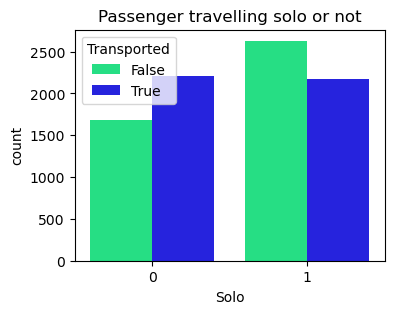

```python
# Feature extraction
printmd("**feature extraction**", color="#08FC84")
printmd("**before**", color="#0804FC")
print("xy_train: ", xy_train.shape)
print("x_test: ", x_test.shape)

for data in x_cleaner:
    # Adding new feature (['Solo'] from ['Group_size'])
    data['Solo']=(data['Group_size']==1).astype(int)

printmd("**after**", color="#0804FC")
print("xy_train: ", xy_train.shape)
print("x_test: ", x_test.shape)

# Plotting new feature
plt.figure(figsize=(4,3))
sns.countplot(data=xy_train, x='Solo', hue='Transported', palette=custom_pallete)
plt.title('Passenger travelling solo or not')
```

##### 2.1.2.3.2 ['Cabin']

Cabin is a variable where the passenger is staying. This variable has deck/num/side pattern. We will split this variable using its delimiter

```python
xy_train['Cabin'].head(3)
```

```
0    B/0/P
1    F/0/S
2    A/0/S
Name: Cabin, dtype: object
```

First we need to check the null value before spliting the variable

```python
print(xy_train['Cabin'].isna().sum())
```

```
199
```

Because its a descriptive variable and we havent split the variable yet. We need to fill the null value with a dummy

Now we are ready to split the variable

**feature extraction**

**before**

```
xy_train:  (8693, 20)
x_test:  (4277, 19)
```

**after**

```
xy_train:  (8693, 22)
x_test:  (4277, 21)
```

```
(0.0, 1900.0)
```

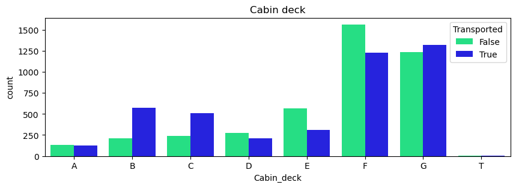

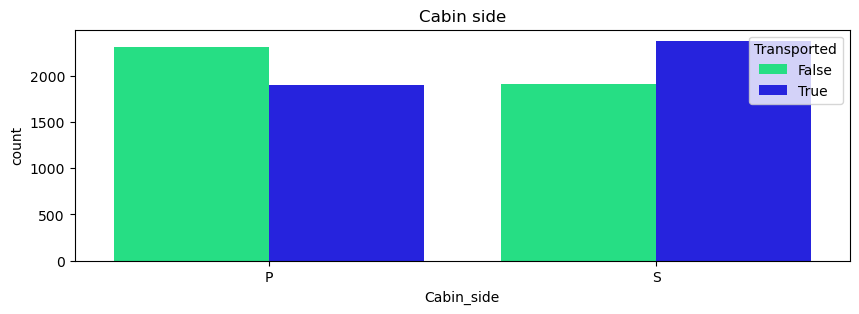

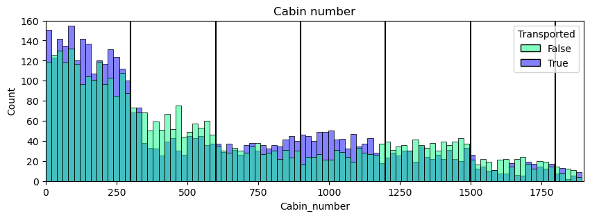

```python
# Feature extraction
printmd("**feature extraction**", color="#08FC84")
printmd("**before**", color="#0804FC")
print("xy_train: ", xy_train.shape)
print("x_test: ", x_test.shape)

for data in x_cleaner:
    # Filling missing values (dummy)
    data['Cabin'].fillna('Z/9999/Z', inplace=True)
    # Adding new features (['Cabin_deck', 'Cabin_number', 'Cabin_side'] from ['Cabin'])
    data['Cabin_deck'] = data['Cabin'].apply(lambda x: x.split('/')[0])
    data['Cabin_number'] = data['Cabin'].apply(lambda x: x.split('/')[1]).astype(int)
    data['Cabin_side'] = data['Cabin'].apply(lambda x: x.split('/')[2])
    # Replacing current values (dummy with nan)
    data.loc[data['Cabin_deck']=='Z', 'Cabin_deck']=np.nan
    data.loc[data['Cabin_number']==9999, 'Cabin_number']=np.nan
    data.loc[data['Cabin_side']=='Z', 'Cabin_side']=np.nan
    # Dropping current feature
    data.drop('Cabin', axis=1, inplace=True)

printmd("**after**", color="#0804FC")
print("xy_train: ", xy_train.shape)
print("x_test: ", x_test.shape)

# Plotting new features
fig=plt.figure(figsize=(10,3))
sns.countplot(data=xy_train, x='Cabin_deck', hue='Transported', order=['A','B','C','D','E','F','G','T'], palette=custom_pallete)
plt.title('Cabin deck')

fig=plt.figure(figsize=(10,3))
sns.countplot(data=xy_train, x='Cabin_side', hue='Transported', palette=custom_pallete)
plt.title('Cabin side')

fig=plt.figure(figsize=(10,3))
sns.histplot(data=xy_train, x='Cabin_number', hue='Transported', binwidth=20, palette=custom_pallete)
plt.vlines(300, ymin=0, ymax=200, color='black')
plt.vlines(600, ymin=0, ymax=200, color='black')
plt.vlines(900, ymin=0, ymax=200, color='black')
plt.vlines(1200, ymin=0, ymax=200, color='black')
plt.vlines(1500, ymin=0, ymax=200, color='black')
plt.vlines(1800, ymin=0, ymax=200, color='black')
plt.title('Cabin number')
plt.ylim([0,160])
plt.xlim([0,1900])
```

```python
sum(xy_train['Cabin_deck']=='T')
```

```
5
```

The ['Cabin_number'] has unique patterns, since it has a very high cardinality, i will discretize into smaller range value

**feature extraction**

**before**

```
xy_train:  (8693, 22)
x_test:  (4277, 21)
```

**after**

```
xy_train:  (8693, 29)
x_test:  (4277, 28)
```

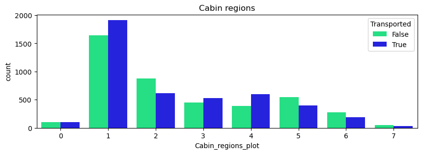

```python
# Feature extraction
printmd("**feature extraction**", color="#08FC84")
printmd("**before**", color="#0804FC")
print("xy_train: ", xy_train.shape)
print("x_test: ", x_test.shape)

for data in x_cleaner:
    # (1) Discretizing current feature (['Cabin_number'].unique() == ['Cabin_region1','Cabin_region2', 'Cabin_region3', 'Cabin_region4', 'Cabin_region5', 'Cabin_region6', 'Cabin_region7'])
    # (1) Adding new features (One-Hot Encoding) (['Cabin_number'] to [['Cabin_region1','Cabin_region2', 'Cabin_region3', 'Cabin_region4', 'Cabin_region5', 'Cabin_region6', 'Cabin_region7']])
    data['Cabin_region1']=(data['Cabin_number']<300).astype(int)
    data['Cabin_region2']=((data['Cabin_number']>=300) & (data['Cabin_number']<600)).astype(int)
    data['Cabin_region3']=((data['Cabin_number']>=600) & (data['Cabin_number']<900)).astype(int)
    data['Cabin_region4']=((data['Cabin_number']>=900) & (data['Cabin_number']<1200)).astype(int)
    data['Cabin_region5']=((data['Cabin_number']>=1200) & (data['Cabin_number']<1500)).astype(int)
    data['Cabin_region6']=((data['Cabin_number']>=1500) & (data['Cabin_number']<1800)).astype(int)
    data['Cabin_region7']=(data['Cabin_number']>=1800).astype(int)

# Plotting new features
plt.figure(figsize=(10,3))
xy_train['Cabin_regions_plot']=(xy_train['Cabin_region1']+2*xy_train['Cabin_region2']+3*xy_train['Cabin_region3']+4*xy_train['Cabin_region4']+5*xy_train['Cabin_region5']+6*xy_train['Cabin_region6']+7*xy_train['Cabin_region7']).astype(int)
sns.countplot(data=xy_train, x='Cabin_regions_plot', hue='Transported', palette=custom_pallete)
plt.title('Cabin regions')
xy_train.drop('Cabin_regions_plot', axis=1, inplace=True)

printmd("**after**", color="#0804FC")
print("xy_train: ", xy_train.shape)
print("x_test: ", x_test.shape)
```

```python
# Checking missing values
m_train = pd.DataFrame({'x_train(Σ)': xy_train.isnull().sum(),'x_train(%)': xy_train.isnull().sum() / len(x_train) * 100})
m_train = m_train[m_train['x_train(Σ)'] > 0]
m_train.sort_values(by='x_train(Σ)', ascending=False, inplace=True)
print(f"There are {m_train.shape[0]} features having missing data in training set.")

m_test = pd.DataFrame({'x_test(Σ)': x_test.isnull().sum(),'x_test(%)': x_test.isnull().sum() / len(x_test) * 100})
m_test = m_test[m_test['x_test(Σ)'] > 0]
m_test.sort_values(by='x_test(Σ)', ascending=False, inplace=True)
print(f"There are {m_test.shape[0]} features having missing data in test set.")

missing = pd.concat([m_train, m_test], axis=1)
missing
```

```
There are 4 features having missing data in training set.
There are 4 features having missing data in test set.
```

|  | x_train(Σ) | x_train(%) | x_test(Σ) | x_test(%) |
| --- | --- | --- | --- | --- |
| Name | 200 | 2.300702 | 94 | 2.197802 |
| Cabin_deck | 199 | 2.289198 | 100 | 2.338087 |
| Cabin_number | 199 | 2.289198 | 100 | 2.338087 |
| Cabin_side | 199 | 2.289198 | 100 | 2.338087 |

##### 2.1.2.3.3 ['Name']

```python
xy_train['Name'].head(3)
```

```
0    Maham Ofracculy
1       Juanna Vines
2      Altark Susent
Name: Name, dtype: object
```

```python
    # Calculate family size from last name.
    # Replace NaN's with outliers for now (so we can split feature)
```

**feature extraction**

**before**

```
xy_train:  (8693, 29)
x_test:  (4277, 28)
```

**after**

```
xy_train:  (8693, 30)
x_test:  (4277, 29)
```

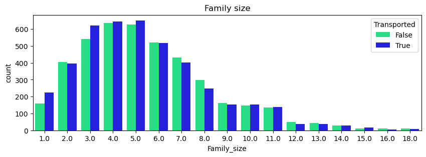

```python
# Feature extraction
printmd("**feature extraction**", color="#08FC84")
printmd("**before**", color="#0804FC")
print("xy_train: ", xy_train.shape)
print("x_test: ", x_test.shape)

for data in x_cleaner:
    # Filling missing value (dummy)
    data['Name'].fillna('Unknown Unknown', inplace=True)
    # Adding new feature (['Surname'] from ['Name'])
    data['Surname']=data['Name'].str.split().str[-1]
    # Adding new feature (['Family_size'] from ['Surname'])
    data['Family_size']=data['Surname'].map(lambda x: data['Surname'].value_counts()[x])
    # Replacing current values (dummy to nan)
    data.loc[data['Surname']=='Unknown','Surname']=np.nan
    data.loc[data['Family_size']>100,'Family_size']=np.nan
    # Dropping current feature
    data.drop('Name', axis=1, inplace=True)

printmd("**after**", color="#0804FC")
print("xy_train: ", xy_train.shape)
print("x_test: ", x_test.shape)

# Plotting new feature
plt.figure(figsize=(10,3))
sns.countplot(data=xy_train, x='Family_size', hue='Transported', palette=custom_pallete)
plt.title('Family size')
```

#### 2.1.2.4 Recap

```
['PassengerID'] to ['Group', 'Group_size', 'Solo'].
['Cabin'] to ['Cabin_deck', 'Cabin_number', 'Cabin_side', 'Cabin_region']. drop ['Cabin']
['Name'] to ['Surname', 'Family_size']. drop ['Name']
```

```python
# summary
# missing value
    # missing value in ['Age', 'RoomService', 'FoodCourt', 'ShoppingMall', 'Spa', 'VRDeck'] filled with mean

# Feature extraction
    # added ['Group'] from ['PassengerId']
        # added ['Group_size'] from ['Group']
            # added ['Solo'] from ['Group_size']
    # added ['Cabin_deck'] from ['Cabin']
    # added ['Cabin_number'] from ['Cabin']
        # added ['Cabin_region1'] from ['Cabin_number']
        # added ['Cabin_region2'] from ['Cabin_number']
        # added ['Cabin_region3'] from ['Cabin_number']
        # added ['Cabin_region4'] from ['Cabin_number']
        # added ['Cabin_region5'] from ['Cabin_number']
        # added ['Cabin_region6'] from ['Cabin_number']
        # added ['Cabin_region7'] from ['Cabin_number']
    # added ['Cabin_side'] from ['Cabin']
    # added ['Surname'] from ['Name']
            # added ['Family_size'] from ['Surname']
```

```python
# Checking missing values
m_train = pd.DataFrame({'x_train(Σ)': xy_train.isnull().sum(),'x_train(%)': xy_train.isnull().sum() / len(x_train) * 100})
m_train = m_train[m_train['x_train(Σ)'] > 0]
m_train.sort_values(by='x_train(Σ)', ascending=False, inplace=True)
print(f"There are {m_train.shape[0]} features having missing data in training set.")

m_test = pd.DataFrame({'x_test(Σ)': x_test.isnull().sum(),'x_test(%)': x_test.isnull().sum() / len(x_test) * 100})
m_test = m_test[m_test['x_test(Σ)'] > 0]
m_test.sort_values(by='x_test(Σ)', ascending=False, inplace=True)
print(f"There are {m_test.shape[0]} features having missing data in test set.")

missing = pd.concat([m_train, m_test], axis=1)
missing
```

```
There are 5 features having missing data in training set.
There are 4 features having missing data in test set.
```

|  | x_train(Σ) | x_train(%) | x_test(Σ) | x_test(%) |
| --- | --- | --- | --- | --- |
| Surname | 200 | 2.300702 | 94.0 | 2.197802 |
| Family_size | 200 | 2.300702 | NaN | NaN |
| Cabin_deck | 199 | 2.289198 | 100.0 | 2.338087 |
| Cabin_number | 199 | 2.289198 | 100.0 | 2.338087 |
| Cabin_side | 199 | 2.289198 | 100.0 | 2.338087 |

```python
xy_train.info()
```

```
<class 'pandas.core.frame.DataFrame'>
RangeIndex: 8693 entries, 0 to 8692
Data columns (total 30 columns):
 #   Column         Non-Null Count  Dtype
---  ------         --------------  -----
 0   PassengerId    8693 non-null   object
 1   HomePlanet     8693 non-null   object
 2   CryoSleep      8693 non-null   bool
 3   Destination    8693 non-null   object
 4   Age            8693 non-null   float64
 5   VIP            8693 non-null   bool
 6   RoomService    8693 non-null   float64
 7   FoodCourt      8693 non-null   float64
 8   ShoppingMall   8693 non-null   float64
 9   Spa            8693 non-null   float64
```

[output cut: 22 more lines]

## 2.2 Inter variables

### 2.2.1 ['Surname']

```python
for data in x_cleaner:
    # Joint distribution of Group and Surname
    GSN_gb=data[data['Group_size']>1].groupby(['Group','Surname'])['Surname'].size().unstack().fillna(0)

    # The majority (83%) of groups contain only 1 family. So let's fill missing surnames according to the majority surname in that group.
    # Missing values before
    SN_bef=data['Surname'].isna().sum()

    # Passengers with missing Surname and in a group with known majority Surname
    GSN_index=data[data['Surname'].isna()][(data[data['Surname'].isna()]['Group']).isin(GSN_gb.index)].index

    # Fill corresponding missing values
    data.loc[GSN_index,'Surname']=data.iloc[GSN_index,:]['Group'].map(lambda x: GSN_gb.idxmax(axis=1)[x])

    # Print number of missing values left
    print('#Surname missing values before:',SN_bef)
    print('#Surname missing values after:',data['Surname'].isna().sum())

    # Replace NaN's with outliers (so we can use map)
    data['Surname'].fillna('Unknown', inplace=True)

    # Update family size feature
    data['Family_size']=data['Surname'].map(lambda x: data['Surname'].value_counts()[x])

    # Put NaN's back in place of outliers
    data.loc[data['Surname']=='Unknown','Surname']=np.nan

    # Say unknown surname means no family
    data.loc[data['Family_size']>100,'Family_size']=0
```

```
#Surname missing values before: 200
#Surname missing values after: 104
#Surname missing values before: 94
#Surname missing values after: 51
```

### 2.2.2 ['Cabin_side']

```python
for data in x_cleaner:
    # Joint distribution of Group and Cabin features
    GCD_gb=data[data['Group_size']>1].groupby(['Group','Cabin_deck'])['Cabin_deck'].size().unstack().fillna(0)
    GCN_gb=data[data['Group_size']>1].groupby(['Group','Cabin_number'])['Cabin_number'].size().unstack().fillna(0)
    GCS_gb=data[data['Group_size']>1].groupby(['Group','Cabin_side'])['Cabin_side'].size().unstack().fillna(0)

    # Everyone in the same group is also on the same cabin side. For cabin deck and cabin number there is also a fairly good (but not perfect) correlation with group.
    # Missing values before
    CS_bef=data['Cabin_side'].isna().sum()

    # Passengers with missing Cabin side and in a group with known Cabin side
    GCS_index=data[data['Cabin_side'].isna()][(data[data['Cabin_side'].isna()]['Group']).isin(GCS_gb.index)].index

    # Fill corresponding missing values
    data.loc[GCS_index,'Cabin_side']=data.iloc[GCS_index,:]['Group'].map(lambda x: GCS_gb.idxmax(axis=1)[x])

    # Print number of missing values left
    print('#Cabin_side missing values before:',CS_bef)
    print('#Cabin_side missing values after:',data['Cabin_side'].isna().sum())
```

```
#Cabin_side missing values before: 199
#Cabin_side missing values after: 99
#Cabin_side missing values before: 100
#Cabin_side missing values after: 63
```

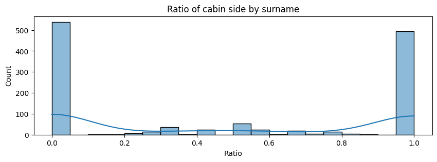

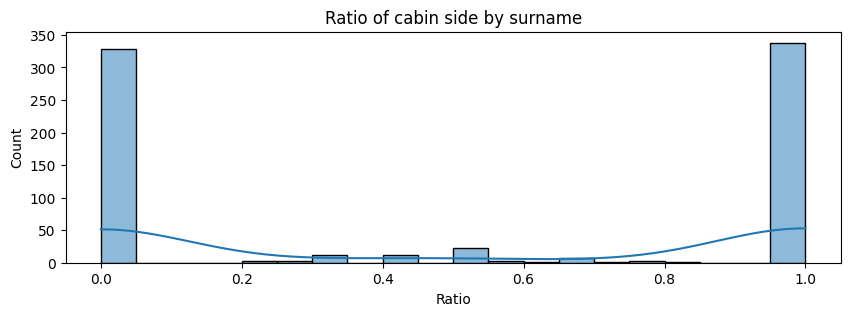

```python
for data in x_cleaner:
    # Joint distribution of Surname and Cabin side
    SCS_gb=data[data['Group_size']>1].groupby(['Surname','Cabin_side'])['Cabin_side'].size().unstack().fillna(0)

    # Ratio of sides
    SCS_gb['Ratio']=SCS_gb['P']/(SCS_gb['P']+SCS_gb['S'])

    # Histogram of ratio
    plt.figure(figsize=(10,3))
    sns.histplot(SCS_gb['Ratio'], kde=True, binwidth=0.05)
    plt.title('Ratio of cabin side by surname')
```

```python
# Print proportion
print('Percentage of families all on the same cabin side:', 100*np.round((SCS_gb['Ratio'].isin([0,1])).sum()/len(SCS_gb),3),'%')

# Another view of the same information
SCS_gb.head()
```

```
Percentage of families all on the same cabin side: 91.0 %
```

| Cabin_side Surname | P | S | Ratio |
| --- | --- | --- | --- |
| Acobsond | 3.0 | 0.0 | 1.0 |
| Aginge | 3.0 | 0.0 | 1.0 |
| Aillyber | 3.0 | 0.0 | 1.0 |
| Aindlylid | 0.0 | 1.0 | 0.0 |
| Airdring | 0.0 | 2.0 | 0.0 |

```python
# Missing values before
CS_bef=data['Cabin_side'].isna().sum()

# Drop ratio column
#SCS_gb.drop('Ratio', axis=1, inplace=True)

for data in x_cleaner:
    # Passengers with missing Cabin side and in a family with known Cabin side
    SCS_index=data[data['Cabin_side'].isna()][(data[data['Cabin_side'].isna()]['Surname']).isin(SCS_gb.index)].index

    # Fill corresponding missing values
    data.loc[SCS_index,'Cabin_side']=data.iloc[SCS_index,:]['Surname'].map(lambda x: SCS_gb.idxmax(axis=1)[x])

    # Drop surname (we don't need it anymore)
    data.drop('Surname', axis=1, inplace=True)

    # Print number of missing values left
    print('#Cabin_side missing values before:',CS_bef)
    print('#Cabin_side missing values after:',data['Cabin_side'].isna().sum())
```

```
#Cabin_side missing values before: 63
#Cabin_side missing values after: 74
#Cabin_side missing values before: 63
#Cabin_side missing values after: 45
```

```python
for data in x_cleaner:
    # Value counts
    data['Cabin_side'].value_counts()

    # Missing values before
    CS_bef=data['Cabin_side'].isna().sum()

    # Fill remaining missing values with outlier
    data.loc[data['Cabin_side'].isna(),'Cabin_side']='Z'

    # Print number of missing values left
    print('#Cabin_side missing values before:',CS_bef)
    print('#Cabin_side missing values after:',data['Cabin_side'].isna().sum())
```

```
#Cabin_side missing values before: 74
#Cabin_side missing values after: 0
#Cabin_side missing values before: 45
#Cabin_side missing values after: 0
```

### 2.2.3 ['Cabin_deck']

```python
for data in x_cleaner:
    # Missing values before
    CD_bef=data['Cabin_deck'].isna().sum()

    # Passengers with missing Cabin deck and in a group with known majority Cabin deck
    GCD_index=data[data['Cabin_deck'].isna()][(data[data['Cabin_deck'].isna()]['Group']).isin(GCD_gb.index)].index

    # Fill corresponding missing values
    data.loc[GCD_index,'Cabin_deck']=data.iloc[GCD_index,:]['Group'].map(lambda x: GCD_gb.idxmax(axis=1)[x])

    # Print number of missing values left
    print('#Cabin_deck missing values before:',CD_bef)
    print('#Cabin_deck missing values after:',data['Cabin_deck'].isna().sum())
```

```
#Cabin_deck missing values before: 199
#Cabin_deck missing values after: 199
#Cabin_deck missing values before: 100
#Cabin_deck missing values after: 63
```

```python
for data in x_cleaner:
    # Joint distribution
    data.groupby(['HomePlanet','Destination','Solo','Cabin_deck'])['Cabin_deck'].size().unstack().fillna(0)
    '''
    Passengers from Mars are most likely in deck F.
    Passengers from Europa are (more or less) most likely in deck C if travelling solo and deck B otherwise.
    Passengers from Earth are (more or less) most likely in deck G.
    We will fill in missing values according to where the mode appears in these subgroups.
    '''
    # Missing values before
    CD_bef=data['Cabin_deck'].isna().sum()

    # Fill missing values using the mode
    na_rows_CD=data.loc[data['Cabin_deck'].isna(),'Cabin_deck'].index
    data.loc[data['Cabin_deck'].isna(),'Cabin_deck']=data.groupby(['HomePlanet','Destination','Solo'])['Cabin_deck'].transform(lambda x: x.fillna(pd.Series.mode(x)[0]))[na_rows_CD]

    # Print number of missing values left
    print('#Cabin_deck missing values before:',CD_bef)
    print('#Cabin_deck missing values after:',data['Cabin_deck'].isna().sum())
```

```
#Cabin_deck missing values before: 199
#Cabin_deck missing values after: 0
#Cabin_deck missing values before: 63
#Cabin_deck missing values after: 0
```

## 4 Cabin Number

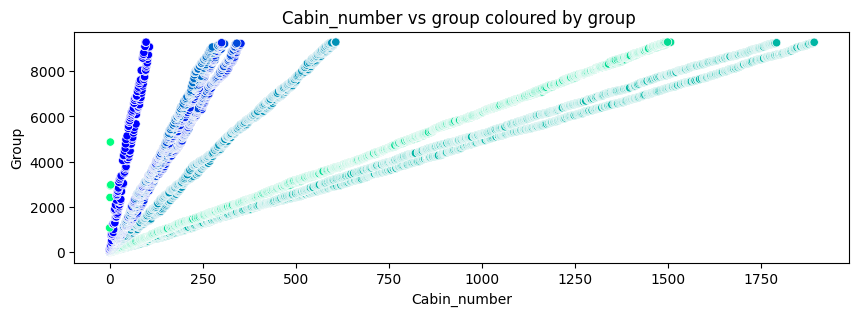

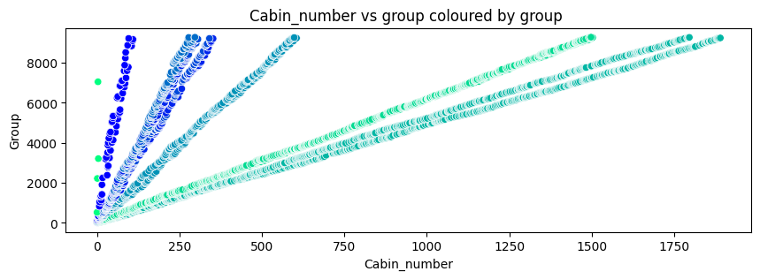

```python
for data in x_cleaner:
    # Scatterplot
    import sklearn
    from sklearn.preprocessing import OneHotEncoder, LabelEncoder
    plt.figure(figsize=(10,3))
    sns.scatterplot(x=data['Cabin_number'], y=data['Group'], c=LabelEncoder().fit_transform(data.loc[~data['Cabin_number'].isna(),'Cabin_deck']), cmap=plt.cm.winter)
    plt.title('Cabin_number vs group coloured by group ')
```

```python
print("before")
print("xy_train: ", xy_train.shape)
print("x_test: ", x_test.shape, "\n")
from sklearn import linear_model

for data in x_cleaner:
    # Missing values before
    CN_bef=data['Cabin_number'].isna().sum()
    print('#Cabin_number missing values before:',CN_bef)
    # Extrapolate linear relationship on a deck by deck basis
    for deck in ['A', 'B', 'C', 'D', 'E', 'F', 'G']:
        # Features and labels
        X_CN=data.loc[~(data['Cabin_number'].isna()) & (data['Cabin_deck']==deck),'Group']
        y_CN=data.loc[~(data['Cabin_number'].isna()) & (data['Cabin_deck']==deck),'Cabin_number']
        X_test_CN=data.loc[(data['Cabin_number'].isna()) & (data['Cabin_deck']==deck),'Group']

        if not X_test_CN.empty:
            # Linear regression
            model_CN=sklearn.linear_model.LinearRegression()
            model_CN.fit(X_CN.values.reshape(-1, 1), y_CN)
            preds_CN=model_CN.predict(X_test_CN.values.reshape(-1, 1))

            # Fill missing values with predictions
            data.loc[(data['Cabin_number'].isna()) & (data['Cabin_deck']==deck),'Cabin_number']=preds_CN.astype(int)

    # Print number of missing values left
    print('#Cabin_number missing values before:',CN_bef)
    print('#Cabin_number missing values after:',data['Cabin_number'].isna().sum())

    # One-hot encode cabin regions
    data['Cabin_region1']=(data['Cabin_number']<300).astype(int)
    data['Cabin_region2']=((data['Cabin_number']>=300) & (data['Cabin_number']<600)).astype(int)
    data['Cabin_region3']=((data['Cabin_number']>=600) & (data['Cabin_number']<900)).astype(int)
    data['Cabin_region4']=((data['Cabin_number']>=900) & (data['Cabin_number']<1200)).astype(int)
    data['Cabin_region5']=((data['Cabin_number']>=1200) & (data['Cabin_number']<1500)).astype(int)
    data['Cabin_region6']=((data['Cabin_number']>=1500) & (data['Cabin_number']<1800)).astype(int)
    data['Cabin_region7']=(data['Cabin_number']>=1800).astype(int)

print("after")
print("xy_train: ", xy_train.shape)
print("x_test: ", x_test.shape)
```

```
before
xy_train:  (8693, 30)
x_test:  (4277, 28)

#Cabin_number missing values before: 199
#Cabin_number missing values before: 199
#Cabin_number missing values after: 0
#Cabin_number missing values before: 100
#Cabin_number missing values before: 100
#Cabin_number missing values after: 0
after
xy_train:  (8693, 30)
x_test:  (4277, 28)
```

```python
# Checking missing values
m_train = pd.DataFrame({'x_train(Σ)': xy_train.isnull().sum(),'x_train(%)': xy_train.isnull().sum() / len(x_train) * 100})
m_train = m_train[m_train['x_train(Σ)'] > 0]
m_train.sort_values(by='x_train(Σ)', ascending=False, inplace=True)
print(f"There are {m_train.shape[0]} features having missing data in training set.")

m_test = pd.DataFrame({'x_test(Σ)': x_test.isnull().sum(),'x_test(%)': x_test.isnull().sum() / len(x_test) * 100})
m_test = m_test[m_test['x_test(Σ)'] > 0]
m_test.sort_values(by='x_test(Σ)', ascending=False, inplace=True)
print(f"There are {m_test.shape[0]} features having missing data in test set.")

missing = pd.concat([m_train, m_test], axis=1)
missing
```

[output not shown]

[output not shown]

## Convert Formats

```python
#CONVERT: convert objects to category using Label Encoder for train and test/validation dataset

#code categorical data
print("before")
print("xy_train: ", xy_train.shape)
print("x_test: ", x_test.shape, "\n")

label = LabelEncoder()

for data in x_cleaner:
    # Adding new features (Label Encoding)
    data['HomePlanet_Code'] = label.fit_transform(data['HomePlanet'])
    data['CryoSleep_Code'] = label.fit_transform(data['CryoSleep'])
    data['Destination_Code'] = label.fit_transform(data['Destination'])
    data['VIP_Code'] = label.fit_transform(data['VIP'])
    data['Age_group_Code'] = label.fit_transform(data['Age_group'])
    data['Cabin_deck_Code'] = label.fit_transform(data['Cabin_deck'])
    data['Cabin_side_Code'] = label.fit_transform(data['Cabin_side'])

print("after")
print("xy_train: ", xy_train.shape)
print("x_test: ", x_test.shape)
```

```
before
xy_train:  (8693, 30)
x_test:  (4277, 28)

after
xy_train:  (8693, 37)
x_test:  (4277, 35)
```

```python
print("before")
print("xy_train: ", xy_train.shape)
print("x_test: ", x_test.shape, "\n")

for dataset in x_cleaner:
    # Dropping current features
    dataset.drop('HomePlanet', axis=1, inplace=True)
    dataset.drop('CryoSleep', axis=1, inplace=True)
    dataset.drop('Destination', axis=1, inplace=True)
    dataset.drop('VIP', axis=1, inplace=True)
    dataset.drop('Age_group', axis=1, inplace=True)
    dataset.drop('Cabin_deck', axis=1, inplace=True)
    dataset.drop('Cabin_side', axis=1, inplace=True)

print("after")
print("xy_train: ", xy_train.shape)
print("x_test: ", x_test.shape)
```

```
before
xy_train:  (8693, 37)
x_test:  (4277, 35)

after
xy_train:  (8693, 30)
x_test:  (4277, 28)
```

```python
x_train.shape
```

```
(8693, 28)
```

```python
x_test.shape
```

```
(4277, 28)
```

```python
y_train.head(3)
```

|  | Transported |
| --- | --- |
| 0 | False |
| 1 | True |
| 2 | False |

```python
y_train['Transported'] = label.fit_transform(y_train['Transported'])
```

```python
y_train.head(3)
```

|  | Transported |
| --- | --- |
| 0 | 0 |
| 1 | 1 |
| 2 | 0 |

```python
x_train.head(1)
```

|  | PassengerId | Age | RoomService | FoodCourt | ShoppingMall | Spa | VRDeck | Expenditure | No_spending | Group | ... | Cabin_region6 | Cabin_region7 | Family_size | HomePlanet_Code | CryoSleep_Code | Destination_Code | VIP_Code | Age_group_Code | Cabin_deck_Code | Cabin_side_Code |
| --- | --- | --- | --- | --- | --- | --- | --- | --- | --- | --- | --- | --- | --- | --- | --- | --- | --- | --- | --- | --- | --- |
| 0 | 0001_01 | 39.0 | 0.0 | 0.0 | 0.0 | 0.0 | 0.0 | 0.0 | 1 | 1 | ... | 0 | 0 | 1 | 1 | 0 | 2 | 0 | 4 | 1 | 0 |

1 rows × 28 columns

# 4. Model

```python
x_traincp = x_train.copy(deep=True)
y_traincp = y_train.copy(deep=True)
x_testcp = x_test.copy(deep=True)

x_traincp = x_traincp.drop(['PassengerId'], axis=1)
x_testcp = x_testcp.drop(['PassengerId'], axis=1)

# Convert pandas_dataframe to numpy_array
print(type(x_traincp))
print(type(y_traincp))
print(type(x_test))
print("x_train: ", x_traincp.shape)
print("y_train: ", y_traincp.shape)
print("x_test: ", x_test.shape, "\n")

x_train_arr = np.asanyarray(x_traincp)
y_train_arr = np.asanyarray(y_traincp)
x_test_arr = np.asanyarray(x_testcp)

print(type(x_train_arr))
print(type(y_train_arr))
print(type(x_test_arr))
print("x_train: ", x_train_arr.shape)
print("y_train: ", y_train_arr.shape)
print("x_test: ", x_test_arr.shape)
```

```
<class 'pandas.core.frame.DataFrame'>
<class 'pandas.core.frame.DataFrame'>
<class 'pandas.core.frame.DataFrame'>
x_train:  (8693, 27)
y_train:  (8693, 1)
x_test:  (4277, 28)

<class 'numpy.ndarray'>
<class 'numpy.ndarray'>
<class 'numpy.ndarray'>
x_train:  (8693, 27)
y_train:  (8693, 1)
x_test:  (4277, 27)
```

## 4.1 Logistic Regression

```python
# Recall/Sensitivity/TruePositiveRate
# Precision
```

```python
from sklearn.linear_model import LogisticRegression
model = LogisticRegression()

# Cross Validation with K=5 (80%train_train, 20%train_validation)
from sklearn.model_selection import cross_val_score
scores_accuracy = cross_val_score(model, x_train_arr, y_train_arr, cv=5, scoring=None)
print("Accuracy (Cross Validation) scores:", np.round(scores_accuracy, 4))
print("Accuracy (Cross Validation) scores mean: {}".format(np.round(scores_accuracy.mean(), 4)))
scores_recall = cross_val_score(model, x_train_arr, y_train_arr, cv=5, scoring='recall')
print("Recall (Cross Validation) scores:", np.round(scores_recall, 4))
print("Recall (Cross Validation) scores mean: {}".format(np.round(scores_recall.mean(), 4)))
scores_precision = cross_val_score(model, x_train_arr, y_train_arr, cv=5, scoring='precision')
print("Precision (Cross Validation) scores:", np.round(scores_precision, 4))
print("Precision (Cross Validation) scores mean: {}".format(np.round(scores_precision.mean(), 4)))

# Fit the model
model.fit(x_train_arr,y_train)

# Training (100%train, 100%train)
score_accuracy = model.score(x_train_arr,y_train_arr)
print("\nAccuracy score: {}".format(np.round(score_accuracy, 4)))
y_train_arr_pred = model.predict(x_train_arr)
from sklearn.metrics import recall_score
score_recall = recall_score(y_train_arr, y_train_arr_pred)
print("Recall score:", np.round(score_recall, 4))
from sklearn.metrics import precision_score
score_precision = precision_score(y_train_arr, y_train_arr_pred)
print("Precision score:", np.round(score_precision, 4))

y_test_pred = model.predict(x_test_arr)
```

```
Accuracy (Cross Validation) scores: [0.7821 0.7694 0.774  0.7906 0.7675]
Accuracy (Cross Validation) scores mean: 0.7767
Recall (Cross Validation) scores: [0.8356 0.879  0.839  0.8651 0.92  ]
Recall (Cross Validation) scores mean: 0.8678
Precision (Cross Validation) scores: [0.757  0.723  0.7447 0.7547 0.7068]
Precision (Cross Validation) scores mean: 0.7372

Accuracy score: 0.7797
Recall score: 0.8764
Precision score: 0.7363
```

Accuracy Score (Test) from Kaggle: 0.78302

```python
# Convert the y_test for submission
y_test_pred = pd.DataFrame(y_test_pred)
submission1 = x_test['PassengerId']
submission1 = pd.DataFrame(submission1)
submission1 = submission1.join(y_test_pred, how='outer')
submission1 = submission1.rename(columns={0:'Transported'})
submission1['Transported'].replace(1, 'True', inplace=True)
submission1['Transported'].replace(0, 'False', inplace=True)
submission1.to_csv('submission1 (Logistic Regression).csv', index = False)
submission1.head(5)
```

|  | PassengerId | Transported |
| --- | --- | --- |
| 0 | 0013_01 | True |
| 1 | 0018_01 | False |
| 2 | 0019_01 | True |
| 3 | 0021_01 | True |
| 4 | 0023_01 | True |

## 4.2 Random Forest

```python
from sklearn.ensemble import RandomForestClassifier
model = RandomForestClassifier(random_state=60)

# Cross Validation with K=5 (80%train_train, 20%train_validation)
from sklearn.model_selection import cross_val_score
scores_accuracy = cross_val_score(model, x_train_arr, y_train_arr, cv=5, scoring=None)
print("Accuracy (Cross Validation) scores:", np.round(scores_accuracy, 4))
print("Accuracy (Cross Validation) scores mean: {}".format(np.round(scores_accuracy.mean(), 4)))
scores_recall = cross_val_score(model, x_train_arr, y_train_arr, cv=5, scoring='recall')
print("Recall (Cross Validation) scores:", np.round(scores_recall, 4))
print("Recall (Cross Validation) scores mean: {}".format(np.round(scores_recall.mean(), 4)))
scores_precision = cross_val_score(model, x_train_arr, y_train_arr, cv=5, scoring='precision')
print("Precision (Cross Validation) scores:", np.round(scores_precision, 4))
print("Precision (Cross Validation) scores mean: {}".format(np.round(scores_precision.mean(), 4)))

# Fit the model
model.fit(x_train_arr,y_train)

# Training (100%train, 100%train)
score_accuracy = model.score(x_train_arr,y_train_arr)
print("\nAccuracy score: {}".format(np.round(score_accuracy, 4)))
y_train_arr_pred = model.predict(x_train_arr)
from sklearn.metrics import recall_score
score_recall = recall_score(y_train_arr, y_train_arr_pred)
print("Recall score:", np.round(score_recall, 4))
from sklearn.metrics import precision_score
score_precision = precision_score(y_train_arr, y_train_arr_pred)
print("Precision score:", np.round(score_precision, 4))

y_test_pred = model.predict(x_test_arr)
```

```
Accuracy (Cross Validation) scores: [0.6429 0.7297 0.7964 0.8188 0.7394]
Accuracy (Cross Validation) scores mean: 0.7454
Recall (Cross Validation) scores: [0.3014 0.6164 0.8505 0.8731 0.504 ]
Recall (Cross Validation) scores mean: 0.6291
Precision (Cross Validation) scores: [0.967  0.8012 0.7696 0.7893 0.9587]
Precision (Cross Validation) scores mean: 0.8572

Accuracy score: 0.9998
Recall score: 0.9998
Precision score: 0.9998
```

Accuracy Score (Test) from Kaggle: 0.79775

```python
# Convert the y_test for submission
y_test_pred = pd.DataFrame(y_test_pred)
submission2 = x_test['PassengerId']
submission2 = pd.DataFrame(submission2)
submission2 = submission2.join(y_test_pred, how='outer')
submission2 = submission2.rename(columns={0:'Transported'})
submission2['Transported'].replace(1, 'True', inplace=True)
submission2['Transported'].replace(0, 'False', inplace=True)
submission2.to_csv('submission2 (Random Forest).csv', index = False)
submission2.head(5)
```

|  | PassengerId | Transported |
| --- | --- | --- |
| 0 | 0013_01 | False |
| 1 | 0018_01 | False |
| 2 | 0019_01 | True |
| 3 | 0021_01 | True |
| 4 | 0023_01 | False |